# W3cubDocs

/Matplotlib 3.1

# matplotlib.transforms

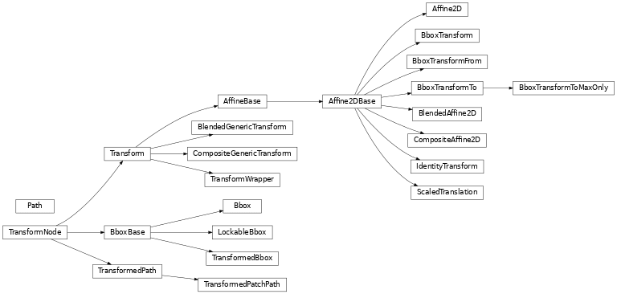

matplotlib includes a framework for arbitrary geometric transformations that is used determine the final position of all elements drawn on the canvas.

Transforms are composed into trees of `TransformNode` objects whose actual value depends on their children. When the contents of children change, their parents are automatically invalidated. The next time an invalidated transform is accessed, it is recomputed to reflect those changes. This invalidation/caching approach prevents unnecessary recomputations of transforms, and contributes to better interactive performance.

For example, here is a graph of the transform tree used to plot data to the graph:

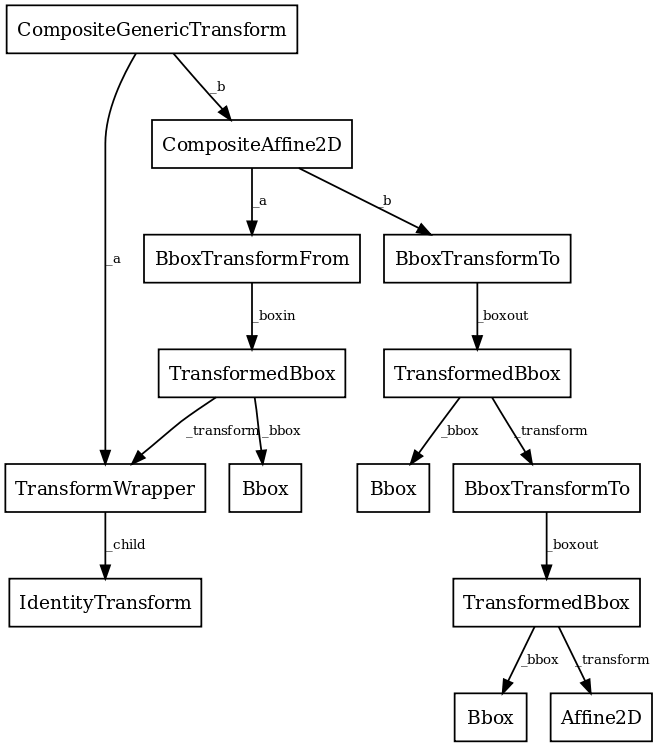

The framework can be used for both affine and non-affine transformations. However, for speed, we want use the backend renderers to perform affine transformations whenever possible. Therefore, it is possible to perform just the affine or non-affine part of a transformation on a set of data. The affine is always assumed to occur after the non-affine. For any transform:

```
full transform == non-affine part + affine part
```

The backends are not expected to handle non-affine transformations themselves.

**`class matplotlib.transforms.Affine2D(matrix=None, **kwargs)` [[source]](https://matplotlib.org/3.1.1/_modules/matplotlib/transforms.html#Affine2D)**

Bases: `matplotlib.transforms.Affine2DBase`

A mutable 2D affine transformation.

Initialize an Affine transform from a 3x3 numpy float array:

```
a c e
b d f
0 0 1
```

If *matrix* is None, initialize with the identity transform.

**`clear(self)` [[source]](https://matplotlib.org/3.1.1/_modules/matplotlib/transforms.html#Affine2D.clear)**

Reset the underlying matrix to the identity transform.

**`static from_values(a, b, c, d, e, f)` [[source]](https://matplotlib.org/3.1.1/_modules/matplotlib/transforms.html#Affine2D.from_values)**

(staticmethod) Create a new Affine2D instance from the given values:

```
a c e
b d f
0 0 1
```

.

**`get_matrix(self)` [[source]](https://matplotlib.org/3.1.1/_modules/matplotlib/transforms.html#Affine2D.get_matrix)**

Get the underlying transformation matrix as a 3x3 numpy array:

```
a c e
b d f
0 0 1
```

.

**`static identity()` [[source]](https://matplotlib.org/3.1.1/_modules/matplotlib/transforms.html#Affine2D.identity)**

(staticmethod) Return a new `Affine2D` object that is the identity transform.

Unless this transform will be mutated later on, consider using the faster `IdentityTransform` class instead.

**`rotate(self, theta)` [[source]](https://matplotlib.org/3.1.1/_modules/matplotlib/transforms.html#Affine2D.rotate)**

Add a rotation (in radians) to this transform in place.

Returns *self*, so this method can easily be chained with more calls to `rotate()`, `rotate_deg()`, `translate()` and `scale()`.

**`rotate_around(self, x, y, theta)` [[source]](https://matplotlib.org/3.1.1/_modules/matplotlib/transforms.html#Affine2D.rotate_around)**

Add a rotation (in radians) around the point (x, y) in place.

Returns *self*, so this method can easily be chained with more calls to `rotate()`, `rotate_deg()`, `translate()` and `scale()`.

**`rotate_deg(self, degrees)` [[source]](https://matplotlib.org/3.1.1/_modules/matplotlib/transforms.html#Affine2D.rotate_deg)**

Add a rotation (in degrees) to this transform in place.

Returns *self*, so this method can easily be chained with more calls to `rotate()`, `rotate_deg()`, `translate()` and `scale()`.

**`rotate_deg_around(self, x, y, degrees)` [[source]](https://matplotlib.org/3.1.1/_modules/matplotlib/transforms.html#Affine2D.rotate_deg_around)**

Add a rotation (in degrees) around the point (x, y) in place.

Returns *self*, so this method can easily be chained with more calls to `rotate()`, `rotate_deg()`, `translate()` and `scale()`.

**`scale(self, sx, sy=None)` [[source]](https://matplotlib.org/3.1.1/_modules/matplotlib/transforms.html#Affine2D.scale)**

Adds a scale in place.

If *sy* is None, the same scale is applied in both the *x*- and *y*-directions.

Returns *self*, so this method can easily be chained with more calls to `rotate()`, `rotate_deg()`, `translate()` and `scale()`.

**`set(self, other)` [[source]](https://matplotlib.org/3.1.1/_modules/matplotlib/transforms.html#Affine2D.set)**

Set this transformation from the frozen copy of another `Affine2DBase` object.

**`set_matrix(self, mtx)` [[source]](https://matplotlib.org/3.1.1/_modules/matplotlib/transforms.html#Affine2D.set_matrix)**

Set the underlying transformation matrix from a 3x3 numpy array:

```
a c e
b d f
0 0 1
```

.

**`skew(self, xShear, yShear)` [[source]](https://matplotlib.org/3.1.1/_modules/matplotlib/transforms.html#Affine2D.skew)**

Adds a skew in place.

*xShear* and *yShear* are the shear angles along the *x*- and *y*-axes, respectively, in radians.

Returns *self*, so this method can easily be chained with more calls to `rotate()`, `rotate_deg()`, `translate()` and `scale()`.

**`skew_deg(self, xShear, yShear)` [[source]](https://matplotlib.org/3.1.1/_modules/matplotlib/transforms.html#Affine2D.skew_deg)**

Adds a skew in place.

*xShear* and *yShear* are the shear angles along the *x*- and *y*-axes, respectively, in degrees.

Returns *self*, so this method can easily be chained with more calls to `rotate()`, `rotate_deg()`, `translate()` and `scale()`.

**`translate(self, tx, ty)` [[source]](https://matplotlib.org/3.1.1/_modules/matplotlib/transforms.html#Affine2D.translate)**

Adds a translation in place.

Returns *self*, so this method can easily be chained with more calls to `rotate()`, `rotate_deg()`, `translate()` and `scale()`.

**`class matplotlib.transforms.Affine2DBase(*args, **kwargs)` [[source]](https://matplotlib.org/3.1.1/_modules/matplotlib/transforms.html#Affine2DBase)**

Bases: `matplotlib.transforms.AffineBase`

The base class of all 2D affine transformations.

2D affine transformations are performed using a 3x3 numpy array:

```
a c e
b d f
0 0 1
```

This class provides the read-only interface. For a mutable 2D affine transformation, use `Affine2D`.

Subclasses of this class will generally only need to override a constructor and `get_matrix()` that generates a custom 3x3 matrix.

**`frozen(self)` [[source]](https://matplotlib.org/3.1.1/_modules/matplotlib/transforms.html#Affine2DBase.frozen)**

Returns a frozen copy of this transform node. The frozen copy will not update when its children change. Useful for storing a previously known state of a transform where `copy.deepcopy()` might normally be used.

**`has_inverse = True`**

**`input_dims = 2`**

**`inverted(self)` [[source]](https://matplotlib.org/3.1.1/_modules/matplotlib/transforms.html#Affine2DBase.inverted)**

Return the corresponding inverse transformation.

The return value of this method should be treated as temporary. An update to *self* does not cause a corresponding update to its inverted copy.

`x === self.inverted().transform(self.transform(x))`

**`is_separable`**

bool(x) -> bool

**`static matrix_from_values(a, b, c, d, e, f)` [[source]](https://matplotlib.org/3.1.1/_modules/matplotlib/transforms.html#Affine2DBase.matrix_from_values)**

(staticmethod) Create a new transformation matrix as a 3x3 numpy array of the form:

```
a c e
b d f
0 0 1
```

**`output_dims = 2`**

**`to_values(self)` [[source]](https://matplotlib.org/3.1.1/_modules/matplotlib/transforms.html#Affine2DBase.to_values)**

Return the values of the matrix as an `(a, b, c, d, e, f)` tuple.

**`transform_affine(self, points)` [[source]](https://matplotlib.org/3.1.1/_modules/matplotlib/transforms.html#Affine2DBase.transform_affine)**

Performs only the affine part of this transformation on the given array of values.

`transform(values)` is always equivalent to `transform_affine(transform_non_affine(values))`.

In non-affine transformations, this is generally a no-op. In affine transformations, this is equivalent to `transform(values)`.

Accepts a numpy array of shape (N x `input_dims`) and returns a numpy array of shape (N x `output_dims`).

Alternatively, accepts a numpy array of length `input_dims` and returns a numpy array of length `output_dims`.

**`transform_point(self, point)` [[source]](https://matplotlib.org/3.1.1/_modules/matplotlib/transforms.html#Affine2DBase.transform_point)**

A convenience function that returns the transformed copy of a single point.

The point is given as a sequence of length `input_dims`. The transformed point is returned as a sequence of length `output_dims`.

**`class matplotlib.transforms.AffineBase(*args, **kwargs)` [[source]](https://matplotlib.org/3.1.1/_modules/matplotlib/transforms.html#AffineBase)**

Bases: `matplotlib.transforms.Transform`

The base class of all affine transformations of any number of dimensions.

**`get_affine(self)` [[source]](https://matplotlib.org/3.1.1/_modules/matplotlib/transforms.html#AffineBase.get_affine)**

Get the affine part of this transform.

**`is_affine = True`**

**`transform(self, values)` [[source]](https://matplotlib.org/3.1.1/_modules/matplotlib/transforms.html#AffineBase.transform)**

Performs the transformation on the given array of values.

Accepts a numpy array of shape (N x `input_dims`) and returns a numpy array of shape (N x `output_dims`).

Alternatively, accepts a numpy array of length `input_dims` and returns a numpy array of length `output_dims`.

**`transform_affine(self, values)` [[source]](https://matplotlib.org/3.1.1/_modules/matplotlib/transforms.html#AffineBase.transform_affine)**

Performs only the affine part of this transformation on the given array of values.

`transform(values)` is always equivalent to `transform_affine(transform_non_affine(values))`.

In non-affine transformations, this is generally a no-op. In affine transformations, this is equivalent to `transform(values)`.

Accepts a numpy array of shape (N x `input_dims`) and returns a numpy array of shape (N x `output_dims`).

Alternatively, accepts a numpy array of length `input_dims` and returns a numpy array of length `output_dims`.

**`transform_non_affine(self, points)` [[source]](https://matplotlib.org/3.1.1/_modules/matplotlib/transforms.html#AffineBase.transform_non_affine)**

Performs only the non-affine part of the transformation.

`transform(values)` is always equivalent to `transform_affine(transform_non_affine(values))`.

In non-affine transformations, this is generally equivalent to `transform(values)`. In affine transformations, this is always a no-op.

Accepts a numpy array of shape (N x `input_dims`) and returns a numpy array of shape (N x `output_dims`).

Alternatively, accepts a numpy array of length `input_dims` and returns a numpy array of length `output_dims`.

**`transform_path(self, path)` [[source]](https://matplotlib.org/3.1.1/_modules/matplotlib/transforms.html#AffineBase.transform_path)**

Returns a transformed path.

*path*: a `Path` instance.

In some cases, this transform may insert curves into the path that began as line segments.

**`transform_path_affine(self, path)` [[source]](https://matplotlib.org/3.1.1/_modules/matplotlib/transforms.html#AffineBase.transform_path_affine)**

Returns a path, transformed only by the affine part of this transform.

*path*: a `Path` instance.

`transform_path(path)` is equivalent to `transform_path_affine(transform_path_non_affine(values))`.

**`transform_path_non_affine(self, path)` [[source]](https://matplotlib.org/3.1.1/_modules/matplotlib/transforms.html#AffineBase.transform_path_non_affine)**

Returns a path, transformed only by the non-affine part of this transform.

*path*: a `Path` instance.

`transform_path(path)` is equivalent to `transform_path_affine(transform_path_non_affine(values))`.

**`class matplotlib.transforms.Bbox(points, **kwargs)` [[source]](https://matplotlib.org/3.1.1/_modules/matplotlib/transforms.html#Bbox)**

Bases: `matplotlib.transforms.BboxBase`

A mutable bounding box.

| Parameters: | **`points : ndarray`** A 2x2 numpy array of the form `[[x0, y0], [x1, y1]]`. |
| --- | --- |

#### Notes

If you need to create a `Bbox` object from another form of data, consider the static methods `unit()`, `from_bounds()` and `from_extents()`.

**`bounds`**

Return (`x0`, `y0`, `width`, `height`).

**`static from_bounds(x0, y0, width, height)` [[source]](https://matplotlib.org/3.1.1/_modules/matplotlib/transforms.html#Bbox.from_bounds)**

(staticmethod) Create a new `Bbox` from *x0*, *y0*, *width* and *height*.

*width* and *height* may be negative.

**`static from_extents(*args)` [[source]](https://matplotlib.org/3.1.1/_modules/matplotlib/transforms.html#Bbox.from_extents)**

(staticmethod) Create a new Bbox from *left*, *bottom*, *right* and *top*.

The *y*-axis increases upwards.

**`get_points(self)` [[source]](https://matplotlib.org/3.1.1/_modules/matplotlib/transforms.html#Bbox.get_points)**

Get the points of the bounding box directly as a numpy array of the form: `[[x0, y0], [x1, y1]]`.

**`ignore(self, value)` [[source]](https://matplotlib.org/3.1.1/_modules/matplotlib/transforms.html#Bbox.ignore)**

Set whether the existing bounds of the box should be ignored by subsequent calls to `update_from_data_xy()`.

**`value : bool`**

- When `True`, subsequent calls to `update_from_data_xy()` will ignore the existing bounds of the `Bbox`.
- When `False`, subsequent calls to `update_from_data_xy()` will include the existing bounds of the `Bbox`.

**`intervalx`**

The pair of *x* coordinates that define the bounding box.

This is not guaranteed to be sorted from left to right.

**`intervaly`**

The pair of *y* coordinates that define the bounding box.

This is not guaranteed to be sorted from bottom to top.

**`minpos`**

**`minposx`**

**`minposy`**

**`mutated(self)` [[source]](https://matplotlib.org/3.1.1/_modules/matplotlib/transforms.html#Bbox.mutated)**

Return whether the bbox has changed since init.

**`mutatedx(self)` [[source]](https://matplotlib.org/3.1.1/_modules/matplotlib/transforms.html#Bbox.mutatedx)**

Return whether the x-limits have changed since init.

**`mutatedy(self)` [[source]](https://matplotlib.org/3.1.1/_modules/matplotlib/transforms.html#Bbox.mutatedy)**

Return whether the y-limits have changed since init.

**`static null()` [[source]](https://matplotlib.org/3.1.1/_modules/matplotlib/transforms.html#Bbox.null)**

(staticmethod) Create a new null `Bbox` from (inf, inf) to (-inf, -inf).

**`p0`**

The first pair of (*x*, *y*) coordinates that define the bounding box.

This is not guaranteed to be the bottom-left corner (for that, use `min`).

**`p1`**

The second pair of (*x*, *y*) coordinates that define the bounding box.

This is not guaranteed to be the top-right corner (for that, use `max`).

**`set(self, other)` [[source]](https://matplotlib.org/3.1.1/_modules/matplotlib/transforms.html#Bbox.set)**

Set this bounding box from the "frozen" bounds of another `Bbox`.

**`set_points(self, points)` [[source]](https://matplotlib.org/3.1.1/_modules/matplotlib/transforms.html#Bbox.set_points)**

Set the points of the bounding box directly from a numpy array of the form: `[[x0, y0], [x1, y1]]`. No error checking is performed, as this method is mainly for internal use.

**`static unit()` [[source]](https://matplotlib.org/3.1.1/_modules/matplotlib/transforms.html#Bbox.unit)**

(staticmethod) Create a new unit `Bbox` from (0, 0) to (1, 1).

**`update_from_data_xy(self, xy, ignore=None, updatex=True, updatey=True)` [[source]](https://matplotlib.org/3.1.1/_modules/matplotlib/transforms.html#Bbox.update_from_data_xy)**

Update the bounds of the `Bbox` based on the passed in data. After updating, the bounds will have positive *width* and *height*; *x0* and *y0* will be the minimal values.

Parameters:

**`xy : ndarray`**

A numpy array of 2D points.

**`ignore : bool, optional`**

- When `True`, ignore the existing bounds of the `Bbox`.
- When `False`, include the existing bounds of the `Bbox`.
- When `None`, use the last value passed to `ignore()`.

**`updatex, updatey : bool, optional`**

When `True`, update the x/y values.

**`update_from_path(self, path, ignore=None, updatex=True, updatey=True)` [[source]](https://matplotlib.org/3.1.1/_modules/matplotlib/transforms.html#Bbox.update_from_path)**

Update the bounds of the `Bbox` based on the passed in data. After updating, the bounds will have positive *width* and *height*; *x0* and *y0* will be the minimal values.

Parameters:

**`path : Path`**

**`ignore : bool, optional`**

- when `True`, ignore the existing bounds of the `Bbox`.
- when `False`, include the existing bounds of the `Bbox`.
- when `None`, use the last value passed to `ignore()`.

**`updatex, updatey : bool, optional`**

When `True`, update the x/y values.

**`x0`**

The first of the pair of *x* coordinates that define the bounding box.

This is not guaranteed to be less than `x1` (for that, use `xmin`).

**`x1`**

The second of the pair of *x* coordinates that define the bounding box.

This is not guaranteed to be greater than `x0` (for that, use `xmax`).

**`y0`**

The first of the pair of *y* coordinates that define the bounding box.

This is not guaranteed to be less than `y1` (for that, use `ymin`).

**`y1`**

The second of the pair of *y* coordinates that define the bounding box.

This is not guaranteed to be greater than `y0` (for that, use `ymax`).

**`class matplotlib.transforms.BboxBase(shorthand_name=None)` [[source]](https://matplotlib.org/3.1.1/_modules/matplotlib/transforms.html#BboxBase)**

Bases: `matplotlib.transforms.TransformNode`

This is the base class of all bounding boxes, and provides read-only access to its data. A mutable bounding box is provided by the `Bbox` class.

The canonical representation is as two points, with no restrictions on their ordering. Convenience properties are provided to get the left, bottom, right and top edges and width and height, but these are not stored explicitly.

Creates a new `TransformNode`.

| Parameters: | **`shorthand_name : str`** A string representing the "name" of the transform. The name carries no significance other than to improve the readability of `str(transform)` when DEBUG=True. |
| --- | --- |

**`anchored(self, c, container=None)` [[source]](https://matplotlib.org/3.1.1/_modules/matplotlib/transforms.html#BboxBase.anchored)**

Return a copy of the `Bbox`, shifted to position *c* within a container.

Parameters:

**`c : (float, float) or str`**

**`container : Bbox, optional`**

The box within which the `Bbox` is positioned; it defaults to the initial `Bbox`.

**`bounds`**

Return (`x0`, `y0`, `width`, `height`).

**`coefs = {'C': (0.5, 0.5), 'E': (1.0, 0.5), 'N': (0.5, 1.0), 'NE': (1.0, 1.0), 'NW': (0, 1.0), 'S': (0.5, 0), 'SE': (1.0, 0), 'SW': (0, 0), 'W': (0, 0.5)}`**

**`contains(self, x, y)` [[source]](https://matplotlib.org/3.1.1/_modules/matplotlib/transforms.html#BboxBase.contains)**

Return whether `(x, y)` is in the bounding box or on its edge.

**`containsx(self, x)` [[source]](https://matplotlib.org/3.1.1/_modules/matplotlib/transforms.html#BboxBase.containsx)**

Return whether *x* is in the closed (`x0`, `x1`) interval.

**`containsy(self, y)` [[source]](https://matplotlib.org/3.1.1/_modules/matplotlib/transforms.html#BboxBase.containsy)**

Return whether *y* is in the closed (`y0`, `y1`) interval.

**`corners(self)` [[source]](https://matplotlib.org/3.1.1/_modules/matplotlib/transforms.html#BboxBase.corners)**

Return the corners of this rectangle as an array of points.

Specifically, this returns the array `[[x0, y0], [x0, y1], [x1, y0], [x1, y1]]`.

**`count_contains(self, vertices)` [[source]](https://matplotlib.org/3.1.1/_modules/matplotlib/transforms.html#BboxBase.count_contains)**

Count the number of vertices contained in the `Bbox`. Any vertices with a non-finite x or y value are ignored.

| Parameters: | **`vertices : Nx2 Numpy array.`** |
| --- | --- |

**`count_overlaps(self, bboxes)` [[source]](https://matplotlib.org/3.1.1/_modules/matplotlib/transforms.html#BboxBase.count_overlaps)**

Count the number of bounding boxes that overlap this one.

| Parameters: | **`bboxes : sequence of BboxBase objects`** |
| --- | --- |

**`expanded(self, sw, sh)` [[source]](https://matplotlib.org/3.1.1/_modules/matplotlib/transforms.html#BboxBase.expanded)**

Construct a `Bbox` by expanding this one around its center by the factors *sw* and *sh*.

**`extents`**

Return (`x0`, `y0`, `x1`, `y1`).

**`frozen(self)` [[source]](https://matplotlib.org/3.1.1/_modules/matplotlib/transforms.html#BboxBase.frozen)**

**`fully_contains(self, x, y)` [[source]](https://matplotlib.org/3.1.1/_modules/matplotlib/transforms.html#BboxBase.fully_contains)**

Return whether `x, y` is in the bounding box, but not on its edge.

**`fully_containsx(self, x)` [[source]](https://matplotlib.org/3.1.1/_modules/matplotlib/transforms.html#BboxBase.fully_containsx)**

Return whether *x* is in the open (`x0`, `x1`) interval.

**`fully_containsy(self, y)` [[source]](https://matplotlib.org/3.1.1/_modules/matplotlib/transforms.html#BboxBase.fully_containsy)**

Return whether *y* is in the open (`y0`, `y1`) interval.

**`fully_overlaps(self, other)` [[source]](https://matplotlib.org/3.1.1/_modules/matplotlib/transforms.html#BboxBase.fully_overlaps)**

Return whether this bounding box overlaps with the other bounding box, not including the edges.

| Parameters: | **`other : BboxBase`** |
| --- | --- |

**`get_points(self)` [[source]](https://matplotlib.org/3.1.1/_modules/matplotlib/transforms.html#BboxBase.get_points)**

**`height`**

The (signed) height of the bounding box.

**`static intersection(bbox1, bbox2)` [[source]](https://matplotlib.org/3.1.1/_modules/matplotlib/transforms.html#BboxBase.intersection)**

Return the intersection of *bbox1* and *bbox2* if they intersect, or None if they don't.

**`intervalx`**

The pair of *x* coordinates that define the bounding box.

This is not guaranteed to be sorted from left to right.

**`intervaly`**

The pair of *y* coordinates that define the bounding box.

This is not guaranteed to be sorted from bottom to top.

**`inverse_transformed(self, transform)` [[source]](https://matplotlib.org/3.1.1/_modules/matplotlib/transforms.html#BboxBase.inverse_transformed)**

Construct a `Bbox` by statically transforming this one by the inverse of *transform*.

**`is_affine = True`**

**`is_bbox = True`**

**`is_unit(self)` [[source]](https://matplotlib.org/3.1.1/_modules/matplotlib/transforms.html#BboxBase.is_unit)**

Return whether this is the unit box (from (0, 0) to (1, 1)).

**`max`**

The top-right corner of the bounding box.

**`min`**

The bottom-left corner of the bounding box.

**`overlaps(self, other)` [[source]](https://matplotlib.org/3.1.1/_modules/matplotlib/transforms.html#BboxBase.overlaps)**

Return whether this bounding box overlaps with the other bounding box.

| Parameters: | **`other : BboxBase`** |
| --- | --- |

**`p0`**

The first pair of (*x*, *y*) coordinates that define the bounding box.

This is not guaranteed to be the bottom-left corner (for that, use `min`).

**`p1`**

The second pair of (*x*, *y*) coordinates that define the bounding box.

This is not guaranteed to be the top-right corner (for that, use `max`).

**`padded(self, p)` [[source]](https://matplotlib.org/3.1.1/_modules/matplotlib/transforms.html#BboxBase.padded)**

Construct a `Bbox` by padding this one on all four sides by *p*.

**`rotated(self, radians)` [[source]](https://matplotlib.org/3.1.1/_modules/matplotlib/transforms.html#BboxBase.rotated)**

Return a new bounding box that bounds a rotated version of this bounding box by the given radians. The new bounding box is still aligned with the axes, of course.

**`shrunk(self, mx, my)` [[source]](https://matplotlib.org/3.1.1/_modules/matplotlib/transforms.html#BboxBase.shrunk)**

Return a copy of the `Bbox`, shrunk by the factor *mx* in the *x* direction and the factor *my* in the *y* direction. The lower left corner of the box remains unchanged. Normally *mx* and *my* will be less than 1, but this is not enforced.

**`shrunk_to_aspect(self, box_aspect, container=None, fig_aspect=1.0)` [[source]](https://matplotlib.org/3.1.1/_modules/matplotlib/transforms.html#BboxBase.shrunk_to_aspect)**

Return a copy of the `Bbox`, shrunk so that it is as large as it can be while having the desired aspect ratio, *box_aspect*. If the box coordinates are relative---that is, fractions of a larger box such as a figure---then the physical aspect ratio of that figure is specified with *fig_aspect*, so that *box_aspect* can also be given as a ratio of the absolute dimensions, not the relative dimensions.

**`size`**

The (signed) width and height of the bounding box.

**`splitx(self, *args)` [[source]](https://matplotlib.org/3.1.1/_modules/matplotlib/transforms.html#BboxBase.splitx)**

Return a list of new `Bbox` objects formed by splitting the original one with vertical lines at fractional positions given by *args*.

**`splity(self, *args)` [[source]](https://matplotlib.org/3.1.1/_modules/matplotlib/transforms.html#BboxBase.splity)**

Return a list of new `Bbox` objects formed by splitting the original one with horizontal lines at fractional positions given by *args*.

**`transformed(self, transform)` [[source]](https://matplotlib.org/3.1.1/_modules/matplotlib/transforms.html#BboxBase.transformed)**

Construct a `Bbox` by statically transforming this one by *transform*.

**`translated(self, tx, ty)` [[source]](https://matplotlib.org/3.1.1/_modules/matplotlib/transforms.html#BboxBase.translated)**

Construct a `Bbox` by translating this one by *tx* and *ty*.

**`static union(bboxes)` [[source]](https://matplotlib.org/3.1.1/_modules/matplotlib/transforms.html#BboxBase.union)**

Return a `Bbox` that contains all of the given *bboxes*.

**`width`**

The (signed) width of the bounding box.

**`x0`**

The first of the pair of *x* coordinates that define the bounding box.

This is not guaranteed to be less than `x1` (for that, use `xmin`).

**`x1`**

The second of the pair of *x* coordinates that define the bounding box.

This is not guaranteed to be greater than `x0` (for that, use `xmax`).

**`xmax`**

The right edge of the bounding box.

**`xmin`**

The left edge of the bounding box.

**`y0`**

The first of the pair of *y* coordinates that define the bounding box.

This is not guaranteed to be less than `y1` (for that, use `ymin`).

**`y1`**

The second of the pair of *y* coordinates that define the bounding box.

This is not guaranteed to be greater than `y0` (for that, use `ymax`).

**`ymax`**

The top edge of the bounding box.

**`ymin`**

The bottom edge of the bounding box.

**`class matplotlib.transforms.BboxTransform(boxin, boxout, **kwargs)` [[source]](https://matplotlib.org/3.1.1/_modules/matplotlib/transforms.html#BboxTransform)**

Bases: `matplotlib.transforms.Affine2DBase`

`BboxTransform` linearly transforms points from one `Bbox` to another `Bbox`.

Create a new `BboxTransform` that linearly transforms points from *boxin* to *boxout*.

**`get_matrix(self)` [[source]](https://matplotlib.org/3.1.1/_modules/matplotlib/transforms.html#BboxTransform.get_matrix)**

Get the Affine transformation array for the affine part of this transform.

**`is_separable = True`**

**`class matplotlib.transforms.BboxTransformFrom(boxin, **kwargs)` [[source]](https://matplotlib.org/3.1.1/_modules/matplotlib/transforms.html#BboxTransformFrom)**

Bases: `matplotlib.transforms.Affine2DBase`

`BboxTransformFrom` linearly transforms points from a given `Bbox` to the unit bounding box.

**`get_matrix(self)` [[source]](https://matplotlib.org/3.1.1/_modules/matplotlib/transforms.html#BboxTransformFrom.get_matrix)**

Get the Affine transformation array for the affine part of this transform.

**`is_separable = True`**

**`class matplotlib.transforms.BboxTransformTo(boxout, **kwargs)` [[source]](https://matplotlib.org/3.1.1/_modules/matplotlib/transforms.html#BboxTransformTo)**

Bases: `matplotlib.transforms.Affine2DBase`

`BboxTransformTo` is a transformation that linearly transforms points from the unit bounding box to a given `Bbox`.

Create a new `BboxTransformTo` that linearly transforms points from the unit bounding box to *boxout*.

**`get_matrix(self)` [[source]](https://matplotlib.org/3.1.1/_modules/matplotlib/transforms.html#BboxTransformTo.get_matrix)**

Get the Affine transformation array for the affine part of this transform.

**`is_separable = True`**

**`class matplotlib.transforms.BboxTransformToMaxOnly(boxout, **kwargs)` [[source]](https://matplotlib.org/3.1.1/_modules/matplotlib/transforms.html#BboxTransformToMaxOnly)**

Bases: `matplotlib.transforms.BboxTransformTo`

`BboxTransformTo` is a transformation that linearly transforms points from the unit bounding box to a given `Bbox` with a fixed upper left of (0, 0).

Create a new `BboxTransformTo` that linearly transforms points from the unit bounding box to *boxout*.

**`get_matrix(self)` [[source]](https://matplotlib.org/3.1.1/_modules/matplotlib/transforms.html#BboxTransformToMaxOnly.get_matrix)**

Get the Affine transformation array for the affine part of this transform.

**`class matplotlib.transforms.BlendedAffine2D(x_transform, y_transform, **kwargs)` [[source]](https://matplotlib.org/3.1.1/_modules/matplotlib/transforms.html#BlendedAffine2D)**

Bases: `matplotlib.transforms.Affine2DBase`

A "blended" transform uses one transform for the *x*-direction, and another transform for the *y*-direction.

This version is an optimization for the case where both child transforms are of type `Affine2DBase`.

Create a new "blended" transform using *x_transform* to transform the *x*-axis and *y_transform* to transform the *y*-axis.

Both *x_transform* and *y_transform* must be 2D affine transforms.

You will generally not call this constructor directly but use the `blended_transform_factory()` function instead, which can determine automatically which kind of blended transform to create.

**`contains_branch_seperately(self, transform)` [[source]](https://matplotlib.org/3.1.1/_modules/matplotlib/transforms.html#BlendedAffine2D.contains_branch_seperately)**

Returns whether the given branch is a sub-tree of this transform on each separate dimension.

A common use for this method is to identify if a transform is a blended transform containing an axes' data transform. e.g.:

```
x_isdata, y_isdata = trans.contains_branch_seperately(ax.transData)
```

**`get_matrix(self)` [[source]](https://matplotlib.org/3.1.1/_modules/matplotlib/transforms.html#BlendedAffine2D.get_matrix)**

Get the Affine transformation array for the affine part of this transform.

**`is_separable = True`**

**`class matplotlib.transforms.BlendedGenericTransform(x_transform, y_transform, **kwargs)` [[source]](https://matplotlib.org/3.1.1/_modules/matplotlib/transforms.html#BlendedGenericTransform)**

Bases: `matplotlib.transforms.Transform`

A "blended" transform uses one transform for the *x*-direction, and another transform for the *y*-direction.

This "generic" version can handle any given child transform in the *x*- and *y*-directions.

Create a new "blended" transform using *x_transform* to transform the *x*-axis and *y_transform* to transform the *y*-axis.

You will generally not call this constructor directly but use the `blended_transform_factory()` function instead, which can determine automatically which kind of blended transform to create.

**`contains_branch(self, other)` [[source]](https://matplotlib.org/3.1.1/_modules/matplotlib/transforms.html#BlendedGenericTransform.contains_branch)**

Return whether the given transform is a sub-tree of this transform.

This routine uses transform equality to identify sub-trees, therefore in many situations it is object id which will be used.

For the case where the given transform represents the whole of this transform, returns True.

**`contains_branch_seperately(self, transform)` [[source]](https://matplotlib.org/3.1.1/_modules/matplotlib/transforms.html#BlendedGenericTransform.contains_branch_seperately)**

Returns whether the given branch is a sub-tree of this transform on each separate dimension.

A common use for this method is to identify if a transform is a blended transform containing an axes' data transform. e.g.:

```
x_isdata, y_isdata = trans.contains_branch_seperately(ax.transData)
```

**`depth`**

Returns the number of transforms which have been chained together to form this Transform instance.

Note

For the special case of a Composite transform, the maximum depth of the two is returned.

**`frozen(self)` [[source]](https://matplotlib.org/3.1.1/_modules/matplotlib/transforms.html#BlendedGenericTransform.frozen)**

Returns a frozen copy of this transform node. The frozen copy will not update when its children change. Useful for storing a previously known state of a transform where `copy.deepcopy()` might normally be used.

**`get_affine(self)` [[source]](https://matplotlib.org/3.1.1/_modules/matplotlib/transforms.html#BlendedGenericTransform.get_affine)**

Get the affine part of this transform.

**`has_inverse`**

**`input_dims = 2`**

**`inverted(self)` [[source]](https://matplotlib.org/3.1.1/_modules/matplotlib/transforms.html#BlendedGenericTransform.inverted)**

Return the corresponding inverse transformation.

The return value of this method should be treated as temporary. An update to *self* does not cause a corresponding update to its inverted copy.

`x === self.inverted().transform(self.transform(x))`

**`is_affine`**

**`is_separable = True`**

**`output_dims = 2`**

**`pass_through = True`**

**`transform_non_affine(self, points)` [[source]](https://matplotlib.org/3.1.1/_modules/matplotlib/transforms.html#BlendedGenericTransform.transform_non_affine)**

Performs only the non-affine part of the transformation.

`transform(values)` is always equivalent to `transform_affine(transform_non_affine(values))`.

In non-affine transformations, this is generally equivalent to `transform(values)`. In affine transformations, this is always a no-op.

Accepts a numpy array of shape (N x `input_dims`) and returns a numpy array of shape (N x `output_dims`).

Alternatively, accepts a numpy array of length `input_dims` and returns a numpy array of length `output_dims`.

**`class matplotlib.transforms.CompositeAffine2D(a, b, **kwargs)` [[source]](https://matplotlib.org/3.1.1/_modules/matplotlib/transforms.html#CompositeAffine2D)**

Bases: `matplotlib.transforms.Affine2DBase`

A composite transform formed by applying transform *a* then transform *b*.

This version is an optimization that handles the case where both *a* and *b* are 2D affines.

Create a new composite transform that is the result of applying transform *a* then transform *b*.

Both *a* and *b* must be instances of `Affine2DBase`.

You will generally not call this constructor directly but use the `composite_transform_factory()` function instead, which can automatically choose the best kind of composite transform instance to create.

**`depth`**

Returns the number of transforms which have been chained together to form this Transform instance.

Note

For the special case of a Composite transform, the maximum depth of the two is returned.

**`get_matrix(self)` [[source]](https://matplotlib.org/3.1.1/_modules/matplotlib/transforms.html#CompositeAffine2D.get_matrix)**

Get the Affine transformation array for the affine part of this transform.

**`class matplotlib.transforms.CompositeGenericTransform(a, b, **kwargs)` [[source]](https://matplotlib.org/3.1.1/_modules/matplotlib/transforms.html#CompositeGenericTransform)**

Bases: `matplotlib.transforms.Transform`

A composite transform formed by applying transform *a* then transform *b*.

This "generic" version can handle any two arbitrary transformations.

Create a new composite transform that is the result of applying transform *a* then transform *b*.

You will generally not call this constructor directly but use the `composite_transform_factory()` function instead, which can automatically choose the best kind of composite transform instance to create.

**`depth`**

**`frozen(self)` [[source]](https://matplotlib.org/3.1.1/_modules/matplotlib/transforms.html#CompositeGenericTransform.frozen)**

Returns a frozen copy of this transform node. The frozen copy will not update when its children change. Useful for storing a previously known state of a transform where `copy.deepcopy()` might normally be used.

**`get_affine(self)` [[source]](https://matplotlib.org/3.1.1/_modules/matplotlib/transforms.html#CompositeGenericTransform.get_affine)**

Get the affine part of this transform.

**`has_inverse`**

**`inverted(self)` [[source]](https://matplotlib.org/3.1.1/_modules/matplotlib/transforms.html#CompositeGenericTransform.inverted)**

Return the corresponding inverse transformation.

The return value of this method should be treated as temporary. An update to *self* does not cause a corresponding update to its inverted copy.

`x === self.inverted().transform(self.transform(x))`

**`is_affine`**

**`is_separable`**

**`pass_through = True`**

**`transform_affine(self, points)` [[source]](https://matplotlib.org/3.1.1/_modules/matplotlib/transforms.html#CompositeGenericTransform.transform_affine)**

Performs only the affine part of this transformation on the given array of values.

`transform(values)` is always equivalent to `transform_affine(transform_non_affine(values))`.

In non-affine transformations, this is generally a no-op. In affine transformations, this is equivalent to `transform(values)`.

Accepts a numpy array of shape (N x `input_dims`) and returns a numpy array of shape (N x `output_dims`).

Alternatively, accepts a numpy array of length `input_dims` and returns a numpy array of length `output_dims`.

**`transform_non_affine(self, points)` [[source]](https://matplotlib.org/3.1.1/_modules/matplotlib/transforms.html#CompositeGenericTransform.transform_non_affine)**

Performs only the non-affine part of the transformation.

`transform(values)` is always equivalent to `transform_affine(transform_non_affine(values))`.

In non-affine transformations, this is generally equivalent to `transform(values)`. In affine transformations, this is always a no-op.

Accepts a numpy array of shape (N x `input_dims`) and returns a numpy array of shape (N x `output_dims`).

Alternatively, accepts a numpy array of length `input_dims` and returns a numpy array of length `output_dims`.

**`transform_path_non_affine(self, path)` [[source]](https://matplotlib.org/3.1.1/_modules/matplotlib/transforms.html#CompositeGenericTransform.transform_path_non_affine)**

Returns a path, transformed only by the non-affine part of this transform.

*path*: a `Path` instance.

`transform_path(path)` is equivalent to `transform_path_affine(transform_path_non_affine(values))`.

**`class matplotlib.transforms.IdentityTransform(*args, **kwargs)` [[source]](https://matplotlib.org/3.1.1/_modules/matplotlib/transforms.html#IdentityTransform)**

Bases: `matplotlib.transforms.Affine2DBase`

A special class that does one thing, the identity transform, in a fast way.

**`frozen(self)` [[source]](https://matplotlib.org/3.1.1/_modules/matplotlib/transforms.html#IdentityTransform.frozen)**

Returns a frozen copy of this transform node. The frozen copy will not update when its children change. Useful for storing a previously known state of a transform where `copy.deepcopy()` might normally be used.

**`get_affine(self)` [[source]](https://matplotlib.org/3.1.1/_modules/matplotlib/transforms.html#IdentityTransform.get_affine)**

Get the affine part of this transform.

**`get_matrix(self)` [[source]](https://matplotlib.org/3.1.1/_modules/matplotlib/transforms.html#IdentityTransform.get_matrix)**

Get the Affine transformation array for the affine part of this transform.

**`inverted(self)` [[source]](https://matplotlib.org/3.1.1/_modules/matplotlib/transforms.html#IdentityTransform.inverted)**

Return the corresponding inverse transformation.

The return value of this method should be treated as temporary. An update to *self* does not cause a corresponding update to its inverted copy.

`x === self.inverted().transform(self.transform(x))`

**`transform(self, points)` [[source]](https://matplotlib.org/3.1.1/_modules/matplotlib/transforms.html#IdentityTransform.transform)**

Performs the transformation on the given array of values.

Accepts a numpy array of shape (N x `input_dims`) and returns a numpy array of shape (N x `output_dims`).

Alternatively, accepts a numpy array of length `input_dims` and returns a numpy array of length `output_dims`.

**`transform_affine(self, points)` [[source]](https://matplotlib.org/3.1.1/_modules/matplotlib/transforms.html#IdentityTransform.transform_affine)**

Performs only the affine part of this transformation on the given array of values.

`transform(values)` is always equivalent to `transform_affine(transform_non_affine(values))`.

In non-affine transformations, this is generally a no-op. In affine transformations, this is equivalent to `transform(values)`.

Accepts a numpy array of shape (N x `input_dims`) and returns a numpy array of shape (N x `output_dims`).

Alternatively, accepts a numpy array of length `input_dims` and returns a numpy array of length `output_dims`.

**`transform_non_affine(self, points)` [[source]](https://matplotlib.org/3.1.1/_modules/matplotlib/transforms.html#IdentityTransform.transform_non_affine)**

Performs only the non-affine part of the transformation.

`transform(values)` is always equivalent to `transform_affine(transform_non_affine(values))`.

In non-affine transformations, this is generally equivalent to `transform(values)`. In affine transformations, this is always a no-op.

Accepts a numpy array of shape (N x `input_dims`) and returns a numpy array of shape (N x `output_dims`).

Alternatively, accepts a numpy array of length `input_dims` and returns a numpy array of length `output_dims`.

**`transform_path(self, path)` [[source]](https://matplotlib.org/3.1.1/_modules/matplotlib/transforms.html#IdentityTransform.transform_path)**

Returns a transformed path.

*path*: a `Path` instance.

In some cases, this transform may insert curves into the path that began as line segments.

**`transform_path_affine(self, path)` [[source]](https://matplotlib.org/3.1.1/_modules/matplotlib/transforms.html#IdentityTransform.transform_path_affine)**

Returns a path, transformed only by the affine part of this transform.

*path*: a `Path` instance.

`transform_path(path)` is equivalent to `transform_path_affine(transform_path_non_affine(values))`.

**`transform_path_non_affine(self, path)` [[source]](https://matplotlib.org/3.1.1/_modules/matplotlib/transforms.html#IdentityTransform.transform_path_non_affine)**

Returns a path, transformed only by the non-affine part of this transform.

*path*: a `Path` instance.

`transform_path(path)` is equivalent to `transform_path_affine(transform_path_non_affine(values))`.

**`class matplotlib.transforms.LockableBbox(bbox, x0=None, y0=None, x1=None, y1=None, **kwargs)` [[source]](https://matplotlib.org/3.1.1/_modules/matplotlib/transforms.html#LockableBbox)**

Bases: `matplotlib.transforms.BboxBase`

A `Bbox` where some elements may be locked at certain values.

When the child bounding box changes, the bounds of this bbox will update accordingly with the exception of the locked elements.

[output not shown]

**`get_points(self)` [[source]](https://matplotlib.org/3.1.1/_modules/matplotlib/transforms.html#LockableBbox.get_points)**

**`locked_x0`**

float or None: The value used for the locked x0.

**`locked_x1`**

float or None: The value used for the locked x1.

**`locked_y0`**

float or None: The value used for the locked y0.

**`locked_y1`**

float or None: The value used for the locked y1.

**`class matplotlib.transforms.ScaledTranslation(xt, yt, scale_trans, **kwargs)` [[source]](https://matplotlib.org/3.1.1/_modules/matplotlib/transforms.html#ScaledTranslation)**

Bases: `matplotlib.transforms.Affine2DBase`

A transformation that translates by *xt* and *yt*, after *xt* and *yt* have been transformed by *scale_trans*.

**`get_matrix(self)` [[source]](https://matplotlib.org/3.1.1/_modules/matplotlib/transforms.html#ScaledTranslation.get_matrix)**

Get the Affine transformation array for the affine part of this transform.

**`class matplotlib.transforms.Transform(shorthand_name=None)` [[source]](https://matplotlib.org/3.1.1/_modules/matplotlib/transforms.html#Transform)**

Bases: `matplotlib.transforms.TransformNode`

The base class of all `TransformNode` instances that actually perform a transformation.

All non-affine transformations should be subclasses of this class. New affine transformations should be subclasses of `Affine2D`.

Subclasses of this class should override the following members (at minimum):

- `input_dims`
- `output_dims`
- `transform()`
- `is_separable`
- `has_inverse`
- `inverted()` (if `has_inverse` is True)

If the transform needs to do something non-standard with `matplotlib.path.Path` objects, such as adding curves where there were once line segments, it should override:

- `transform_path()`

Creates a new `TransformNode`.

| Parameters: | **`shorthand_name : str`** A string representing the "name" of the transform. The name carries no significance other than to improve the readability of `str(transform)` when DEBUG=True. |
| --- | --- |

**`contains_branch(self, other)` [[source]](https://matplotlib.org/3.1.1/_modules/matplotlib/transforms.html#Transform.contains_branch)**

Return whether the given transform is a sub-tree of this transform.

This routine uses transform equality to identify sub-trees, therefore in many situations it is object id which will be used.

For the case where the given transform represents the whole of this transform, returns True.

**`contains_branch_seperately(self, other_transform)` [[source]](https://matplotlib.org/3.1.1/_modules/matplotlib/transforms.html#Transform.contains_branch_seperately)**

Returns whether the given branch is a sub-tree of this transform on each separate dimension.

A common use for this method is to identify if a transform is a blended transform containing an axes' data transform. e.g.:

```
x_isdata, y_isdata = trans.contains_branch_seperately(ax.transData)
```

**`depth`**

Returns the number of transforms which have been chained together to form this Transform instance.

Note

For the special case of a Composite transform, the maximum depth of the two is returned.

**`get_affine(self)` [[source]](https://matplotlib.org/3.1.1/_modules/matplotlib/transforms.html#Transform.get_affine)**

Get the affine part of this transform.

**`get_matrix(self)` [[source]](https://matplotlib.org/3.1.1/_modules/matplotlib/transforms.html#Transform.get_matrix)**

Get the Affine transformation array for the affine part of this transform.

**`has_inverse = False`**

True if this transform has a corresponding inverse transform.

**`input_dims = None`**

The number of input dimensions of this transform. Must be overridden (with integers) in the subclass.

**`inverted(self)` [[source]](https://matplotlib.org/3.1.1/_modules/matplotlib/transforms.html#Transform.inverted)**

Return the corresponding inverse transformation.

The return value of this method should be treated as temporary. An update to *self* does not cause a corresponding update to its inverted copy.

`x === self.inverted().transform(self.transform(x))`

**`is_separable = False`**

True if this transform is separable in the x- and y- dimensions.

**`output_dims = None`**

The number of output dimensions of this transform. Must be overridden (with integers) in the subclass.

**`transform(self, values)` [[source]](https://matplotlib.org/3.1.1/_modules/matplotlib/transforms.html#Transform.transform)**

Performs the transformation on the given array of values.

Accepts a numpy array of shape (N x `input_dims`) and returns a numpy array of shape (N x `output_dims`).

Alternatively, accepts a numpy array of length `input_dims` and returns a numpy array of length `output_dims`.

**`transform_affine(self, values)` [[source]](https://matplotlib.org/3.1.1/_modules/matplotlib/transforms.html#Transform.transform_affine)**

Performs only the affine part of this transformation on the given array of values.

`transform(values)` is always equivalent to `transform_affine(transform_non_affine(values))`.

In non-affine transformations, this is generally a no-op. In affine transformations, this is equivalent to `transform(values)`.

Accepts a numpy array of shape (N x `input_dims`) and returns a numpy array of shape (N x `output_dims`).

Alternatively, accepts a numpy array of length `input_dims` and returns a numpy array of length `output_dims`.

**`transform_angles(self, angles, pts, radians=False, pushoff=1e-05)` [[source]](https://matplotlib.org/3.1.1/_modules/matplotlib/transforms.html#Transform.transform_angles)**

Transforms a set of angles anchored at specific locations.

[output not shown]

**`transform_bbox(self, bbox)` [[source]](https://matplotlib.org/3.1.1/_modules/matplotlib/transforms.html#Transform.transform_bbox)**

Transform the given bounding box.

Note, for smarter transforms including caching (a common requirement for matplotlib figures), see `TransformedBbox`.

**`transform_non_affine(self, values)` [[source]](https://matplotlib.org/3.1.1/_modules/matplotlib/transforms.html#Transform.transform_non_affine)**

Performs only the non-affine part of the transformation.

`transform(values)` is always equivalent to `transform_affine(transform_non_affine(values))`.

In non-affine transformations, this is generally equivalent to `transform(values)`. In affine transformations, this is always a no-op.

Accepts a numpy array of shape (N x `input_dims`) and returns a numpy array of shape (N x `output_dims`).

Alternatively, accepts a numpy array of length `input_dims` and returns a numpy array of length `output_dims`.

**`transform_path(self, path)` [[source]](https://matplotlib.org/3.1.1/_modules/matplotlib/transforms.html#Transform.transform_path)**

Returns a transformed path.

*path*: a `Path` instance.

In some cases, this transform may insert curves into the path that began as line segments.

**`transform_path_affine(self, path)` [[source]](https://matplotlib.org/3.1.1/_modules/matplotlib/transforms.html#Transform.transform_path_affine)**

Returns a path, transformed only by the affine part of this transform.

*path*: a `Path` instance.

`transform_path(path)` is equivalent to `transform_path_affine(transform_path_non_affine(values))`.

**`transform_path_non_affine(self, path)` [[source]](https://matplotlib.org/3.1.1/_modules/matplotlib/transforms.html#Transform.transform_path_non_affine)**

Returns a path, transformed only by the non-affine part of this transform.

*path*: a `Path` instance.

`transform_path(path)` is equivalent to `transform_path_affine(transform_path_non_affine(values))`.

**`transform_point(self, point)` [[source]](https://matplotlib.org/3.1.1/_modules/matplotlib/transforms.html#Transform.transform_point)**

A convenience function that returns the transformed copy of a single point.

The point is given as a sequence of length `input_dims`. The transformed point is returned as a sequence of length `output_dims`.

**`class matplotlib.transforms.TransformNode(shorthand_name=None)` [[source]](https://matplotlib.org/3.1.1/_modules/matplotlib/transforms.html#TransformNode)**

Bases: [`object`](https://docs.python.org/3/library/functions.html#object)

`TransformNode` is the base class for anything that participates in the transform tree and needs to invalidate its parents or be invalidated. This includes classes that are not really transforms, such as bounding boxes, since some transforms depend on bounding boxes to compute their values.

Creates a new `TransformNode`.

| Parameters: | **`shorthand_name : str`** A string representing the "name" of the transform. The name carries no significance other than to improve the readability of `str(transform)` when DEBUG=True. |
| --- | --- |

**`INVALID = 3`**

**`INVALID_AFFINE = 2`**

**`INVALID_NON_AFFINE = 1`**

**`frozen(self)` [[source]](https://matplotlib.org/3.1.1/_modules/matplotlib/transforms.html#TransformNode.frozen)**

Returns a frozen copy of this transform node. The frozen copy will not update when its children change. Useful for storing a previously known state of a transform where `copy.deepcopy()` might normally be used.

**`invalidate(self)` [[source]](https://matplotlib.org/3.1.1/_modules/matplotlib/transforms.html#TransformNode.invalidate)**

Invalidate this `TransformNode` and triggers an invalidation of its ancestors. Should be called any time the transform changes.

**`is_affine = False`**

**`is_bbox = False`**

**`pass_through = False`**

If pass_through is True, all ancestors will always be invalidated, even if 'self' is already invalid.

**`set_children(self, *children)` [[source]](https://matplotlib.org/3.1.1/_modules/matplotlib/transforms.html#TransformNode.set_children)**

Set the children of the transform, to let the invalidation system know which transforms can invalidate this transform. Should be called from the constructor of any transforms that depend on other transforms.

**`class matplotlib.transforms.TransformWrapper(child)` [[source]](https://matplotlib.org/3.1.1/_modules/matplotlib/transforms.html#TransformWrapper)**

Bases: `matplotlib.transforms.Transform`

A helper class that holds a single child transform and acts equivalently to it.

This is useful if a node of the transform tree must be replaced at run time with a transform of a different type. This class allows that replacement to correctly trigger invalidation.

Note that `TransformWrapper` instances must have the same input and output dimensions during their entire lifetime, so the child transform may only be replaced with another child transform of the same dimensions.

*child*: A class:`Transform` instance. This child may later be replaced with `set()`.

**`frozen(self)` [[source]](https://matplotlib.org/3.1.1/_modules/matplotlib/transforms.html#TransformWrapper.frozen)**

Returns a frozen copy of this transform node. The frozen copy will not update when its children change. Useful for storing a previously known state of a transform where `copy.deepcopy()` might normally be used.

**`has_inverse`**

**`is_affine`**

**`is_separable`**

**`pass_through = True`**

**`set(self, child)` [[source]](https://matplotlib.org/3.1.1/_modules/matplotlib/transforms.html#TransformWrapper.set)**

Replace the current child of this transform with another one.

The new child must have the same number of input and output dimensions as the current child.

**`class matplotlib.transforms.TransformedBbox(bbox, transform, **kwargs)` [[source]](https://matplotlib.org/3.1.1/_modules/matplotlib/transforms.html#TransformedBbox)**

Bases: `matplotlib.transforms.BboxBase`

A `Bbox` that is automatically transformed by a given transform. When either the child bounding box or transform changes, the bounds of this bbox will update accordingly.

| Parameters: | **`bbox : Bbox`** **`transform : Transform`** |
| --- | --- |

**`get_points(self)` [[source]](https://matplotlib.org/3.1.1/_modules/matplotlib/transforms.html#TransformedBbox.get_points)**

**`class matplotlib.transforms.TransformedPatchPath(patch)` [[source]](https://matplotlib.org/3.1.1/_modules/matplotlib/transforms.html#TransformedPatchPath)**

Bases: `matplotlib.transforms.TransformedPath`

A `TransformedPatchPath` caches a non-affine transformed copy of the `Patch`. This cached copy is automatically updated when the non-affine part of the transform or the patch changes.

Create a new `TransformedPatchPath` from the given `Patch`.

**`class matplotlib.transforms.TransformedPath(path, transform)` [[source]](https://matplotlib.org/3.1.1/_modules/matplotlib/transforms.html#TransformedPath)**

Bases: `matplotlib.transforms.TransformNode`

A `TransformedPath` caches a non-affine transformed copy of the `Path`. This cached copy is automatically updated when the non-affine part of the transform changes.

Note

Paths are considered immutable by this class. Any update to the path's vertices/codes will not trigger a transform recomputation.

Create a new `TransformedPath` from the given `Path` and `Transform`.

**`get_affine(self)` [[source]](https://matplotlib.org/3.1.1/_modules/matplotlib/transforms.html#TransformedPath.get_affine)**

**`get_fully_transformed_path(self)` [[source]](https://matplotlib.org/3.1.1/_modules/matplotlib/transforms.html#TransformedPath.get_fully_transformed_path)**

Return a fully-transformed copy of the child path.

**`get_transformed_path_and_affine(self)` [[source]](https://matplotlib.org/3.1.1/_modules/matplotlib/transforms.html#TransformedPath.get_transformed_path_and_affine)**

Return a copy of the child path, with the non-affine part of the transform already applied, along with the affine part of the path necessary to complete the transformation.

**`get_transformed_points_and_affine(self)` [[source]](https://matplotlib.org/3.1.1/_modules/matplotlib/transforms.html#TransformedPath.get_transformed_points_and_affine)**

Return a copy of the child path, with the non-affine part of the transform already applied, along with the affine part of the path necessary to complete the transformation. Unlike `get_transformed_path_and_affine()`, no interpolation will be performed.

**`matplotlib.transforms.blended_transform_factory(x_transform, y_transform)` [[source]](https://matplotlib.org/3.1.1/_modules/matplotlib/transforms.html#blended_transform_factory)**

Create a new "blended" transform using *x_transform* to transform the *x*-axis and *y_transform* to transform the *y*-axis.

A faster version of the blended transform is returned for the case where both child transforms are affine.

**`matplotlib.transforms.composite_transform_factory(a, b)` [[source]](https://matplotlib.org/3.1.1/_modules/matplotlib/transforms.html#composite_transform_factory)**

Create a new composite transform that is the result of applying transform a then transform b.

Shortcut versions of the blended transform are provided for the case where both child transforms are affine, or one or the other is the identity transform.

Composite transforms may also be created using the '+' operator, e.g.:

```
c = a + b
```

**`matplotlib.transforms.interval_contains(interval, val)` [[source]](https://matplotlib.org/3.1.1/_modules/matplotlib/transforms.html#interval_contains)**

Check, inclusively, whether an interval includes a given value.

| Parameters: | **`interval : sequence of scalar`** A 2-length sequence, endpoints that define the interval. **`val : scalar`** Value to check is within interval. |
| --- | --- |
| Returns: | **bool** Returns *True* if given *val* is within the *interval*. |

**`matplotlib.transforms.interval_contains_open(interval, val)` [[source]](https://matplotlib.org/3.1.1/_modules/matplotlib/transforms.html#interval_contains_open)**

Check, excluding endpoints, whether an interval includes a given value.

| Parameters: | **`interval : sequence of scalar`** A 2-length sequence, endpoints that define the interval. **`val : scalar`** Value to check is within interval. |
| --- | --- |
| Returns: | **bool** Returns true if given val is within the interval. |

**`matplotlib.transforms.nonsingular(vmin, vmax, expander=0.001, tiny=1e-15, increasing=True)` [[source]](https://matplotlib.org/3.1.1/_modules/matplotlib/transforms.html#nonsingular)**

Modify the endpoints of a range as needed to avoid singularities.

[output not shown]

**`matplotlib.transforms.offset_copy(trans, fig=None, x=0.0, y=0.0, units='inches')` [[source]](https://matplotlib.org/3.1.1/_modules/matplotlib/transforms.html#offset_copy)**

Return a new transform with an added offset.

[output not shown]

© 2012–2018 Matplotlib Development Team. All rights reserved.  
Licensed under the Matplotlib License Agreement.  
https://matplotlib.org/3.1.1/api/transformations.html